[figure not shown]

# Secrets of Misinterpretation

What small local AI models extract from the *Philosophical Transactions*, and how far to trust them

Mathias Johansson (Uppsala University)  
with Cecilia Lundström and Hanna Johansson Flodin (Lund University)  
Secrets to Patents · DEPTH · 13 November 2026

# Background

## Why we care: Secrets to Patents

Trans-Imperial Strategies for Keeping Medicines as Private Assets from 1500 to 1900

- How knowledge moved between **secret** and **shared**
- So the journal raises a specific question: **where did experimental knowledge get made, and how public was that place?**

Principal investigator: Natacha Klein Käfer.

[figure not shown]

[secretstopatents.org](https://secretstopatents.org/)

## The journal

- *Philosophical Transactions* began in 1665. It is the longest-running scientific journal in the world.
- Not a journal as we know it: letters, observations, experiments, book reviews.
- A record of who could speak about nature, from where, and in what form.

## The material

8,545items in the catalogue

222years, 1665 to 1886

455labelled “Experiment” (about 5%)

Two levels of evidence:

- **Metadata for everything:** title, year, authors, label, pages
- **Full text only for the 455 Experiment articles,** read by machine

## The Philosophical Transactions Explorer

[figure not shown]

[figure not shown]

digitalhistory-lund.github.io/  
SecToPat-PhilTransExplorer

Five views: topics, authors, article length, a filtering dashboard, a searchable list of all 8,545 items. Metadata only.

## The letter rises, then disappears

[interactive chart not shown]

Share of items labelled “Letter”, by decade. 1660s covers 1665–69, 1880s covers 1880–86. Titles mentioning a letter show the same collapse.

# Reading

## How the full text was read

The 455 Experiment articles: small AI models, run locally

**Scan to image**each page as a picture

→

**Read the page**vision model turns image into text

→

**Cut out the article**using its title

→

**Extract**was it an experiment? where? who?

8,506 pages of text. **Pink steps are where errors of judgement get in.**

## Monday evening, 8 May 1665

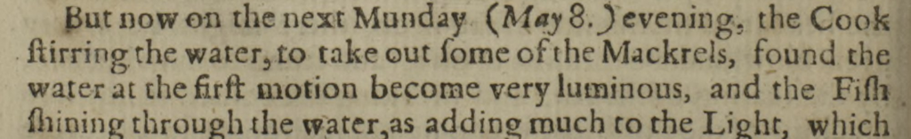

“…the Cook stirring the water, to take out some of the Mackrels, found the water at the first motion become very luminous, and the Fish shining through the water…”

Dr Beale’s report, *Philosophical Transactions*, vol. 1, p. 226. Scan: Royal Society.

## Eight small models, one page

| Model | Size | Trial notes on this page |
| --- | --- | --- |
| qwen3.5:0.8b **(the one we use)** | 0.8B | “Celebrity” for Celerity, misses “begetteth” |
| qwen3.5:2b **(ranked first)** | 2B | Fish shining, Celerity, begetteth all correct |
| qwen3.5:4b | 4B | Keeps long s as f, leaks metadata |
| qwen3-vl:2b | 2B | “Fifth flinching” for Fish shining |
| qwen3-vl:4b | 4B | “flaggatate” for stagnate |
| qwen3-vl:8b | 8B | Page number 126 for 226, no paragraph breaks |
| gemma3:12b | 12B | Drops lines, “cloud” for blow, “Sunday” for Monday |
| medgemma1.5 | 4B | Reorders paragraphs and drops text |

Size is the model’s parameter count in billions. All run locally. One page, judged by hand, so this is a first look and not a benchmark.

## What the machine read

| Printed on the page | The model we chose | Another model we tried |
| --- | --- | --- |
| Celerity of Motion | Celebrity of Motion | Celerity of Motion |
| the Fish shining | the Fish shining | the Fifth flinching |

In 1665 “Fish shining” is printed with a long s: *Fiſh ſhining*.

Each error is plausible. Each reads as fluent English. **That is the problem.**

From a trial of eight small vision models on this page. The trial notes rank a larger model first. We chose a smaller, faster one for 8,506 pages.

## What we asked the model

The answer must fit a fixed form, so every article becomes a row of data.

## Model selection: read them side by side

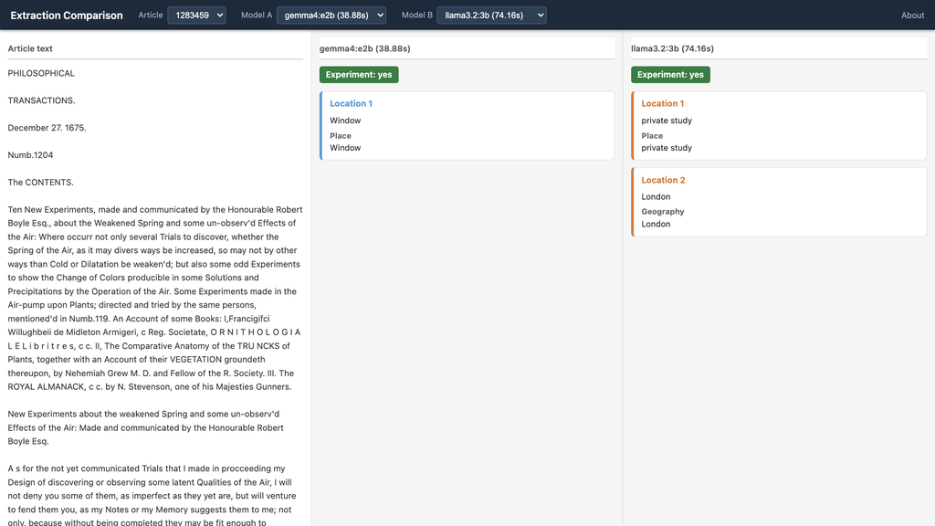

[figure not shown]

digitalhistory-lund.github.io/  
SecToPat-PhilTransModelSelection

Six local models, four articles, the text beside any two outputs.

## One article, six answers

Hauksbee, “An Experiment on the descent of Malt dust in the Evacuated Receiver, at Grefham College”. About 180 words.

| Model | Locations returned |
| --- | --- |
| gemma4:e2b | Receiver · Grefham College · St Paul’s Church-yard |
| llama3.2:3b | Grefham College · London |
| ministral-3:3b **(small version of ours)** | Evacuated Receiver · Receiver |
| phi3.5 | private study or laboratory setting within Grefham College · two more |
| qwen3.5:2b | Grefham College |
| qwen3.5:4b | Grefham College |

“Grefham” is the long s again. St Paul’s Church-yard is the printer’s address at the foot of the page. llama, phi and qwen used an earlier two-question prompt.

## Choosing without an answer key

- A **quick manual comparison**: six models, four articles, read side by side
- **No answer key**, so no accuracy score
- Prompts differed between models
- We compared the 3.8B ministral-3. The pipeline code names the **8.9B** one

## What came out

455articles read

1,409locations

2,032participants

- Most frequent place: **London** (63, and 38 more as “London, England”)
- Most frequent people: **Michael Faraday** 24, **Mr. Fr. Hauksbee** 16, **Robert Boyle** 14
- Not yet tidied: 1,646 different name forms. “Dr. Priestley” and “Joseph Priestley” count apart

## The Extractions Viewer

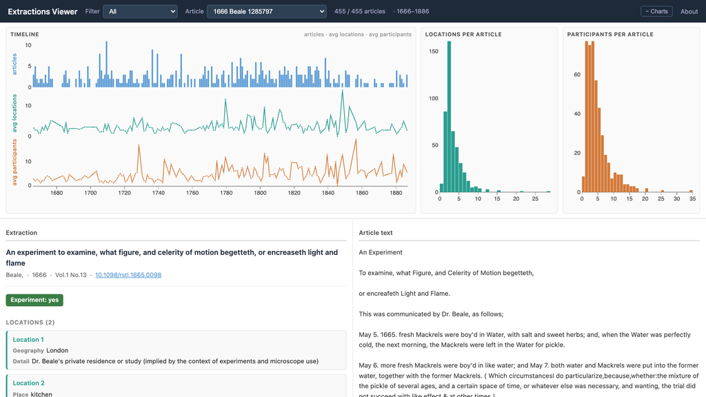

[figure not shown]

digitalhistory-lund.github.io/  
SecToPat-PhilTransExtractions

All 455 articles, each extraction beside its text. Filter by year and result, share a link to any view.

## What a small team can now do

- Models small enough to run **on our own machine**, with no sources sent elsewhere, at **about 17 seconds a page**
- A site and pipeline built by **one person with a coding assistant** (Claude, credited)
- Openly citable: **all three sites have DOIs**

**Building it got cheap. Checking it did not.**

# Failing Forward

## Back to the mackerel

| What the model extracted | In the article? |
| --- | --- |
| London | Never mentioned |
| “Dr. Beale’s private residence or study (implied by the context of experiments and microscope use)” | “private” and “study” never appear. The microscope does |
| kitchen | Never mentioned. A Cook, and “the house”, are |

Checked against the machine-read text of the article, 848 words.

## Models also ignore what they are told

We told the model: *“Do not include apparatus or containers as locations.”*

| Extracted place | Detail, as extracted |
| --- | --- |
| exhausted receiver (same as above) | where the sparrow was placed |
| exhausted receiver (same as above) | floor area where the cat was placed |

And on “is this an experiment?”, 448 of 455 said yes.  
All 455 were already labelled Experiment, so that is agreement, not accuracy.

## We gave the model an example

“private study or laboratory”

26 exact matches. “kitchen” appears 4 times.

## “Private” 144 times. “Public” never.

144of 965 extracted places contain “private”

0contain “public”

- “private study or meeting room (Royal Society)”
- “private study or laboratory (Royal Institution)”
- “private laboratory or workshop (attached to Gresham College)”

## What this leaves us with

**Machines are good for** seeing the shape of a whole archive, finding where to look, and asking new questions of it.

**A human reader is still needed** to decide what a word like *private* means, and to measure how wrong the machine is.

Our categories can shape what the model finds. Check them before you count them.

## Thank you

[figure not shown]

Natacha Klein Käfer, principal investigator  
Mathias Johansson, Cecilia Lundström and Hanna Johansson Flodin, authors  
Contact: Mathias.Johansson@fek.uu.se

[figure not shown]

These slidesdigitalhistory-lund.github.io/  
2026-11-13_DEPTH-philtransexplorer

[figure not shown]

Extractions Viewer[SecToPat-PhilTransExtractions](https://digitalhistory-lund.github.io/SecToPat-PhilTransExtractions/)  
[doi 20502387](https://doi.org/10.5281/zenodo.20502387)

[figure not shown]

Model selection[SecToPat-PhilTransModelSelection](https://digitalhistory-lund.github.io/SecToPat-PhilTransModelSelection/)  
[doi 20502415](https://doi.org/10.5281/zenodo.20502415)

[figure not shown]

Explorer[SecToPat-PhilTransExplorer](https://digitalhistory-lund.github.io/SecToPat-PhilTransExplorer/)  
[doi 20162091](https://doi.org/10.5281/zenodo.20162091)

[figure not shown]

Mathias on LinkedIn[linkedin.com/in/mathiasjoha](https://www.linkedin.com/in/mathiasjoha/)

Sites at digitalhistory-lund.github.io

# Encore

## Backup: The typical article grows from 3 pages to over 20

[interactive chart not shown]

Median pages per item, by decade, for the 8,081 items with usable page numbers. 1880s covers 1880–86.

## Backup: Fewer and fewer items without a named author

[interactive chart not shown]

Share of items with no author listed in the publisher’s metadata, by decade. 1660s covers 1665–69.

## Backup: See for yourself

[figure not shown]

[figure not shown]

digitalhistory-lund.github.io/  
SecToPat-PhilTransExplorer

## Backup: How the catalogue was made

Every item: no AI involved

**Crawl**publisher’s public pages, decade by decade

→

**Index**one database of articles and authors

→

**Aggregate**counts checked to reconcile

→

**Publish**a static website

8,545 records and 8,545 PDFs. The script stops if the totals don’t add up.

## Backup: Even plain metadata misleads

| What you see | What is going on |
| --- | --- |
| Hooke, Robert · Hook, · Hooke, · Hooke’s, Dr. | One person, four “authors” |
| Maskelyne publishes from 1759 to 1879 | Almost certainly two people with one surname |
| “Article” and “Articles” as separate topics | Labels from the publisher’s web pages. Their origin is unknown |
| A 1,005-page reply from Newton | A typing error in the page numbers |